# Assignment 3: Movie Scripts

Ines Perez

2024-03-23

# Text Mining Movie Scripts

```r
#install.packages("tm")
library('tm')
```

```r
library('ggplot2')
library('Matrix')
library('readr')
```

## Overview

Explore the cinematic world through the lens of movie scripts, analyzing narrative structures, character prominence, and thematic elements across genres and periods. This assignment involves dissecting movie scripts to uncover patterns and trends, employing data visualization techniques to present your findings.

## Data

You will work with a dataset of approximately 1000 movie scripts and their metadata. This includes the movie’s title, release date, a brief overview, and parsed script files distinguishing dialogue, character information, and scene descriptions. The data was scraped with [Aveek Saha’s code](https://github.com/Aveek-Saha/Movie-Script-Database).

For your assignment, the movie scripts have already been parsed, metadata has been added, and they should be ready to go. The two input files of relevance are:

- `data\tagged.csv.gz` - contains tagged content portions of all movie scripts. Please rely on the `Dialogue` for analysis.
- `data\metadata.csv` - contains movie metadata from IMDB, including title, release date, genre, IMBD vote average and popularity, etc.

### Tasks for the Assignment

#### 1. Dialogue

### Creating some basic functions for text preprocessing

```r
clean_txt <- function(str_in) {
  tmp_clean_t <- tolower(gsub("[^A-Za-z']", " ", str_in))
  return(trimws(tmp_clean_t))
}

# File reader function
file_reader <- function(path_in) {
  tmp <- tolower(readLines(path_in, encoding = "UTF-8"))
  return(clean_txt(tmp))
}

# Word count function
fun_wrd_cnt <- function(pd_in, col_name_in) {
  library(stringr)
  fun_word <- list()
  topics <- unique(pd_in$label)
  for (topic in topics) {
    wrd_fun <- pd_in[pd_in$label == topic, ]
    str_cat <- paste(wrd_fun[[col_name_in]], collapse = " ")
    fun_word[[topic]] <- table(unlist(str_split(str_cat, "\\s+")))
  }
  return(fun_word)
}

# Remove stop words function
rem_sw <- function(str_in) {
  library(tm)
  sw <- stopwords("en")
  sent <- removeWords(tolower(str_in), sw)
  return(sent)
}

# Stemming function
stem_fun <- function(str_in) {
  library(SnowballC)
  sent <- wordStem(tolower(str_in))
  return(sent)
}

# Token count function
token_count <- function(str_in) {
  tmp <- unlist(str_split(tolower(str_in), "\\s+"))
  return(length(tmp))
}

# Unique token count function
token_count_unique <- function(str_in) {
  tmp <- unique(unlist(str_split(tolower(str_in), "\\s+")))
  return(length(tmp))
}

# Chi-square feature selection function
chi_fun <- function(df_in, label_in, k_in, path_out, name_in) {
  library(C50)
  dim_data <- data.frame(select(df_in, chi.squared(df_in, label_in, n = k_in)$chosen))
  write.csv(dim_data, file = paste0(path_out, "/", name_in, ".csv"), row.names = FALSE)
  return(dim_data)
}
```

#### Reading in our datasets for movie scripts and metadata:

```r
library(tidyverse)
library(dplyr)
df<- read.csv('/Users/inesperezalvarez-pallete/Desktop/tagged.csv')
meta<-read.csv('/Users/inesperezalvarez-pallete/Desktop/metadata.csv')
#subset our dataframe to exclusively mention dialogue
dialogue <- df %>% filter(Tag == 'Dialogue')

grouped<-dialogue %>%
  group_by(movie_id) %>%
  mutate(Content = paste0(Content, collapse = "")) %>% distinct(Content, movie_id)

#grouped
```

Analyze the dialogue content of movie scripts. Transform the dialogue into a tidy data frame, breaking down the text into individual words, removing common stop words and other unnecessary elements. As needed, use the cleaning functions introduced in lecture (or write your own in addition) to remove unnecessary words (stop words), syntax, punctuation, numbers, white space, etc. Visualize the 20 most frequently used words in the dialogues to gain insights into the core thematic elements of the scripts.

```r
#subset our dataframe to exclusively mention dialogue

#create a function for spelling correction
library(hunspell)

# Define a function for spell correction
spell_correct <- function(text) {
  dict <- hunspell::hunspell_load("en_US")
  words <- unlist(strsplit(text, "\\s+"))
  corrected_words <- sapply(words, function(word) {
    if (!hunspell_check(dict, word)) {
      suggestions <- hunspell_suggest(dict, word)
      if (length(suggestions) > 0) {
        return(suggestions[[1]])
      } else {
        return(word)
      }
    } else {
      return(word)
    }
  })
  corrected_text <- paste(corrected_words, collapse = " ")
  return(corrected_text)
}

# Define function for lemmatization
#lemmatize_tokens <- function(tokens) {

#  model <- udpipe_download_model(language = "english")
#  udpipe_model <- udpipe_load_model(model$file_model)
#  lemmatized_tokens <- udpipe_annotate(udpipe_model, tokens)
 # lemmatized_tokens <- as.data.frame(lemmatized_tokens)
#  return(lemmatized_tokens)
#}

library("quanteda")
```

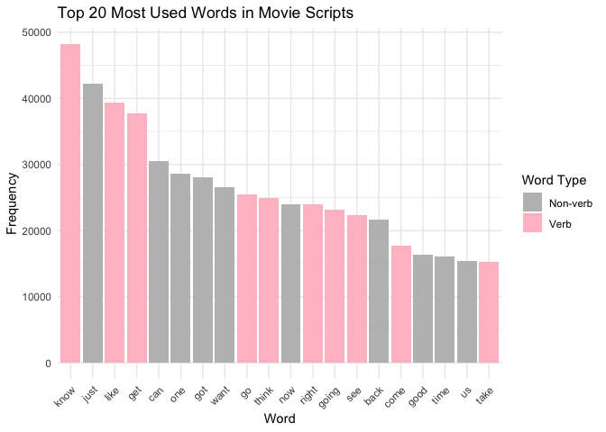

```r
library(udpipe)
library(tm)
library(tokenizers)
library(SnowballC)
library(ggplot2)

# Removing appropriate symbols and extra syntax
tokens <- tokens(as.character(grouped$Content), what = "word",
                 remove_numbers = TRUE,
                 remove_punct = TRUE,
                 remove_separators = TRUE)

# Lowercasing our tokens and removing stopwords. We do not conduct stemming as this might take away from the context of our data
tokens <- tokens_remove(tokens, stopwords("en"))
tokens <- tokens_tolower(tokens)
tokens <- tokens_remove(tokens, '--')
#tokens <- lemmatize_tokens(tokens)

#converting our tokens into a tidy document term matrix
dtm<-dfm(tokens)

#extracting top 20 words
library("quanteda.textstats")
top_20 <- textstat_frequency(dtm, n = 20)
top_20_verbs<-c('know','get', 'like','go','think','going','right','see','come','take')

#visualizing top 20 most frequent words, color coding wether words are verbs or not
# Determine if each word is a verb

# Add a column to indicate if the word is a verb or not
top_20$color <- ifelse(top_20$feature %in% top_20_verbs, "pink", "grey")

# Plot the bar graph
ggplot(top_20, aes(x = reorder(feature, -frequency), y = frequency, fill = color)) +
  geom_bar(stat = "identity") +
  scale_fill_identity() +scale_fill_manual(values = c("pink" = "pink", "grey" = "grey"), name = "Word Type",
                    labels = c("Non-verb", "Verb")) +
  labs(title = "Top 20 Most Used Words in Movie Scripts",x="Word",
       y = "Frequency") +
  theme_minimal() +
  theme(axis.text.x = element_text(angle = 45, hjust = 1))
```

Creating a bar graph visualization for our most frequently used words:

##### b) Word Cloud

Create word clouds for a selection of movies to visualize the most prevalent themes or phrases. Choose a set of movies, either randomly or based on specific criteria, and use their script dialogues to generate the clouds.

```r
#Merging our metadata and our original parsed text data
library(wordcloud)
library(RColorBrewer)
library(tidytable)
colnames(meta)
```

```
##  [1] "id"                "movie_key"         "name"
##  [4] "source"            "file_name"         "script_url"
##  [7] "tmdb_title"        "release_date"      "tmdb_id"
## [10] "overview"          "imdb_title"        "imdb_release_date"
## [13] "imdb_id"           "dialogue"          "charinfo"
## [16] "tagged"            "adult"             "backdrop_path"
## [19] "title"             "original_language" "original_title"
## [22] "poster_path"       "media_type"        "genre_ids"
## [25] "popularity"        "video"             "vote_average"
## [28] "vote_count"        "genres"
```

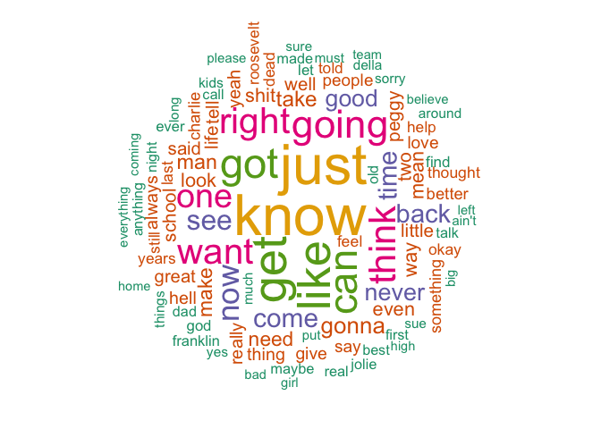

```r
library(tm)
library(tidytext)
library("wordcloud")


grouped[ , 'token'] = NA
grouped$token = sapply(tokens, paste, collapse = " ")

random_indices <- sample(1:nrow(grouped), 5)
cloud_data <- grouped[random_indices, ]

dtm <- TermDocumentMatrix(cloud_data$token)

matrix <- as.matrix(dtm)
words <- sort(rowSums(matrix),decreasing=TRUE)

df <- data.frame(word = names(words),freq=words)

wordcloud(words = df$word, freq = df$freq, min.freq = 1, max.words=100, random.order=FALSE,
          rot.per=0.3, colors=brewer.pal(6,"Dark2"))
```

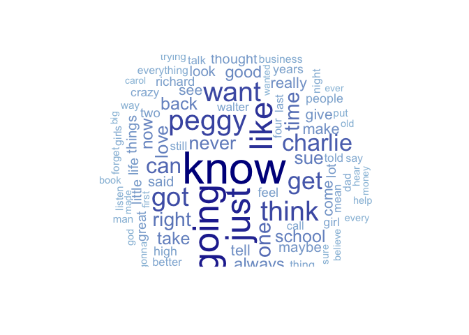

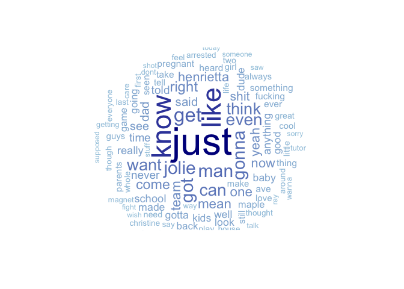

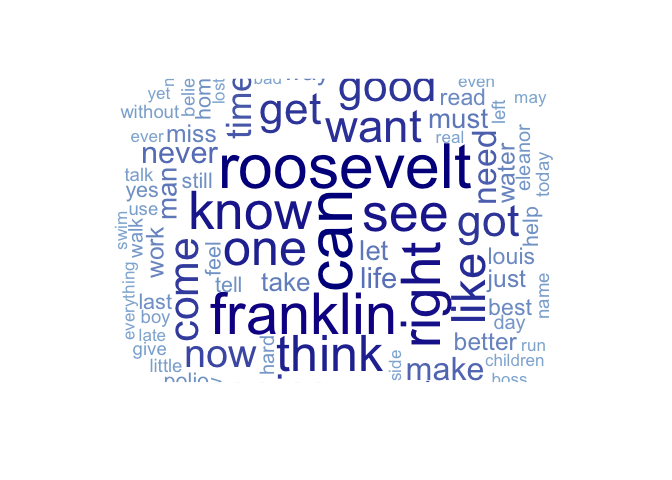

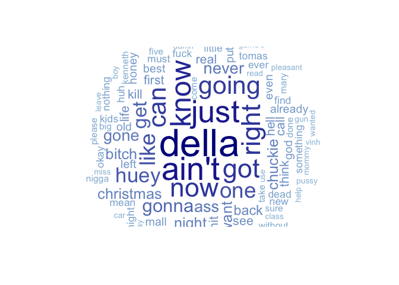

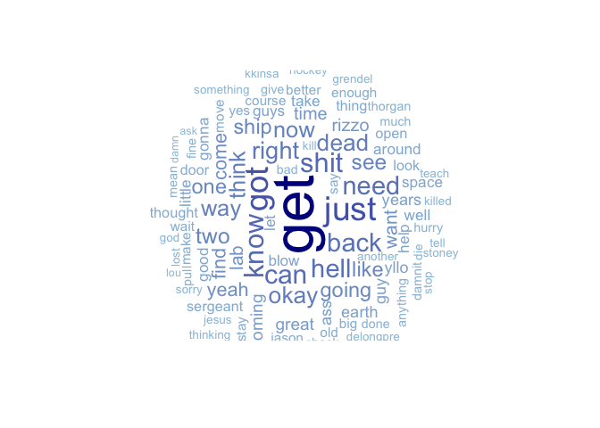

```r
for (i in 1:nrow(cloud_data)) {
  document <- cloud_data[i, ]

  # Create Document Term Matrix (DTM)
  dtm <- TermDocumentMatrix(VectorSource(document$token))
  matrix <- as.matrix(dtm)

  # Get word frequencies
  words <- sort(rowSums(matrix), decreasing=TRUE)
  df <- data.frame(word = names(words), freq = words)

  # Calculate colors based on word frequency
  color_freq <- df$freq / max(df$freq)  # Normalize frequency to [0,1]
  colors <- colorRampPalette(c("lightblue", "darkblue"))(length(color_freq))

  # Create word cloud with color indicating frequency
  wordcloud(words = df$word, freq = df$freq, min.freq = 1, max.words = 100,
            random.order = FALSE, rot.per = 0.3, colors = colors)
}
```

```r
meta$tagged<-sub(".txt$", "",meta$tagged)
#merging meta data with script data
data_joined <- left_join(grouped, meta, by = c("movie_id"="tagged"))
colnames(data_joined)
```

```
##  [1] "Content"           "movie_id"          "token"
##  [4] "id"                "movie_key"         "name"
##  [7] "source"            "file_name"         "script_url"
## [10] "tmdb_title"        "release_date"      "tmdb_id"
## [13] "overview"          "imdb_title"        "imdb_release_date"
## [16] "imdb_id"           "dialogue"          "charinfo"
## [19] "adult"             "backdrop_path"     "title"
## [22] "original_language" "original_title"    "poster_path"
## [25] "media_type"        "genre_ids"         "popularity"
## [28] "video"             "vote_average"      "vote_count"
## [31] "genres"
```

```r
#genre_filter<-filter(data_joined$genres)
```

Word clouds for our randomly selected movie scripts:

##### c) Success in Words

Investigate the correlation between specific words or phrases in movie scripts and their success, measured by viewer ratings or popularity. Utilize a pyramid plot to compare the frequency of the top 10-20 words in both successful and unsuccessful movies.

For this section,we will merge our script text data with our meta data

Interestingly, many of the words most present in successful movies are also present in a high degree of frequency in unpopular movies

```r
library(tidytable)
colnames(meta)
```

```
##  [1] "id"                "movie_key"         "name"
##  [4] "source"            "file_name"         "script_url"
##  [7] "tmdb_title"        "release_date"      "tmdb_id"
## [10] "overview"          "imdb_title"        "imdb_release_date"
## [13] "imdb_id"           "dialogue"          "charinfo"
## [16] "tagged"            "adult"             "backdrop_path"
## [19] "title"             "original_language" "original_title"
## [22] "poster_path"       "media_type"        "genre_ids"
## [25] "popularity"        "video"             "vote_average"
## [28] "vote_count"        "genres"
```

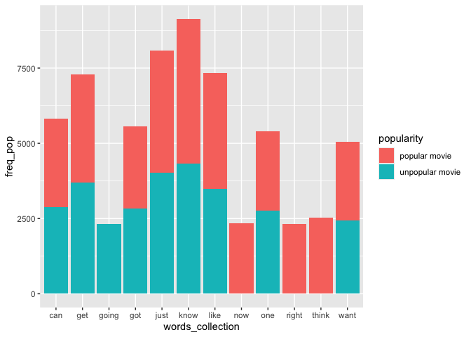

```r
meta$tagged<-sub(".txt$", "",meta$tagged)
#merging meta data with script data
data_joined <- left_join(grouped, meta, by = c("movie_id"="tagged"))



unpop100 <- Corpus(VectorSource(data_joined[1:100,]$token))
dtm <- TermDocumentMatrix(unpop100)
m <- as.matrix(dtm)
v <- sort(rowSums(m),decreasing=TRUE)
d <- data.frame(word = names(v),freq=v)

pop100 <- Corpus(VectorSource(tail(data_joined, 100)$token))
dtm1 <- TermDocumentMatrix(pop100)
m1 <- as.matrix(dtm1)
v1 <- sort(rowSums(m1),decreasing=TRUE)
d1 <- data.frame(word = names(v1),freq=v1)

words_collection <- unique(c(names(v), names(v1)))
freq_pop <- rep(0, length(words_collection))
freq_unpop <- rep(0, length(words_collection))

for (i in 1:length(words_collection)){
  freq_pop[i] <- v[words_collection[i]]
  freq_unpop[i] <- v1[words_collection[i]]
}
freq_pop[is.na(freq_pop)] <- 0
freq_unpop[is.na(freq_unpop)] <- 0
popularity <- vector(length = length(words_collection))
data_c1 <- data.frame(words_collection ,
                     freq_pop, popularity)
data_c1$popularity = 'popular movie'
data_c2 <- data.frame(words_collection ,
                      freq_unpop, popularity)
data_c2$popularity = 'unpopular movie'
colnames(data_c2)[colnames(data_c2) == 'freq_unpop'] <- 'freq_pop'
data_c = bind_rows(data_c1, data_c2)
data_c <- data_c[order(-freq_pop),]
ggplot(data_c[1:20,],
       aes(x = words_collection,
           y = freq_pop,
           fill = popularity)) +
  geom_col()
```

```r
# Clean up movie IDs in meta data
meta$tagged <- sub(".txt$", "", meta$tagged)

# Merge meta data with script data
data_joined <- left_join(grouped, meta, by = c("movie_id" = "tagged"))

# Select top 100 successful and unsuccessful movies based on popularity/ratings
top_100_successful <- head(data_joined[order(data_joined$popularity, decreasing = TRUE), ], 100)
bottom_100_unsuccessful <- head(data_joined[order(data_joined$popularity), ], 100)

# Create function to preprocess text data
preprocess_text <- function(text) {
  text <- tolower(text)
  text <- removePunctuation(text)
  text <- removeNumbers(text)
  text <- removeWords(text, stopwords("en"))
  return(text)
}

# Preprocess text data for successful and unsuccessful movies
successful_corpus <- Corpus(VectorSource(top_100_successful$token))
unsuccessful_corpus <- Corpus(VectorSource(bottom_100_unsuccessful$token))

successful_corpus <- tm_map(successful_corpus, content_transformer(preprocess_text))
unsuccessful_corpus <- tm_map(unsuccessful_corpus, content_transformer(preprocess_text))
```

[figure not shown]

```r
# Create Document Term Matrices (DTMs)
successful_dtm <- DocumentTermMatrix(successful_corpus)
unsuccessful_dtm <- DocumentTermMatrix(unsuccessful_corpus)

# Convert DTMs to matrices
successful_matrix <- as.matrix(successful_dtm)
unsuccessful_matrix <- as.matrix(unsuccessful_dtm)

# Get word frequencies
successful_freq <- rowSums(successful_matrix)
unsuccessful_freq <- rowSums(unsuccessful_matrix)

# Create dataframes for successful and unsuccessful movies
successful_df <- data.frame(word = names(successful_freq), freq = successful_freq)
unsuccessful_df <- data.frame(word = names(unsuccessful_freq), freq = unsuccessful_freq)

# Merge dataframes
merged_df <- merge(successful_df, unsuccessful_df, by = "word", suffixes = c("_successful", "_unsuccessful"))

# Filter top 10-20 words by highest frequency difference
top_words <- merged_df[order(abs(merged_df$freq_successful - merged_df$freq_unsuccessful), decreasing = TRUE), ][1:20, ]

# Calculate frequency difference
top_words$diff <- top_words$freq_successful - top_words$freq_unsuccessful

ggplot(top_words, aes(x = diff, y = reorder(word, diff), label = word)) +
  geom_point(aes(color = ifelse(diff > 0, "Successful", "Unsuccessful")), size = 3) +
  geom_segment(aes(xend = 0, yend = word), color = "grey") +
  geom_text(hjust = ifelse(top_words$diff > 0, 0, 1.2), size = 3) +
  labs(title = "Top Words Correlated with Movie Success", x = "Frequency Difference (Successful - Unsuccessful)", y = NULL, color = "Movie Success") +
  scale_color_manual(values = c("Successful" = "blue", "Unsuccessful" = "red")) +
  theme_minimal() +
  theme(axis.text.y = element_text(size = 8)) +
  guides(color = guide_legend(title = NULL))
```

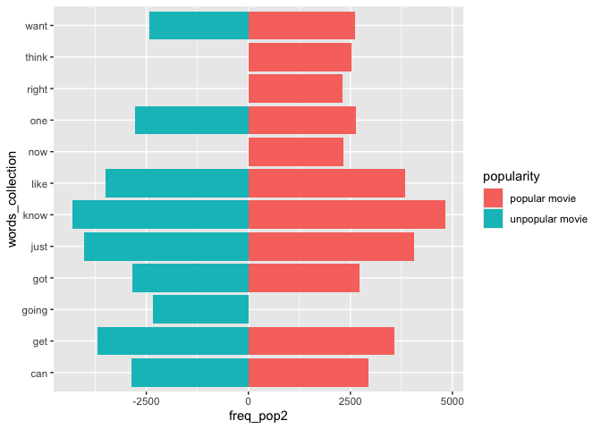

```r
# Create separate data frames for popular and unpopular movies
data_c <- mutate(data_c, freq_pop2 = freq_pop)
popular_data <- data_c[data_c$popularity == 'popular movie', ]
unpopular_data <- data_c[data_c$popularity == 'unpopular movie', ]

if ("unpopular movie" %in% data_c$popularity) {
  data_c$freq_pop2 <- ifelse(data_c$popularity == "unpopular movie", -data_c$freq_pop, data_c$freq_pop2)
} else if ("popular movie" %in% data_c$popularity) {
  data_c$freq_pop2 <- ifelse(data_c$popularity == "popular movie", data_c$freq_pop, data_c$freq_pop2)
}

# Plot for unpopular movies
plot_popular <- ggplot(popular_data[1:20, ], aes(x = freq_pop, y = words_collection)) +
  geom_col(fill = "green") +
  labs(title = "Top 20 Word Frequencies of popular words in Popular Movies",
       x = "Frequency",
       y = "Word") +
  theme_minimal() +
  theme(axis.text.y = element_text(size = 8))

plot_unpopular <- ggplot(unpopular_data[1:20, ], aes(x = freq_unpop, y = words_collection)) +
  geom_col(fill = "red") +
  labs(title = "Top 20 Word Frequencies of popular words in unPopular Movies",
       x = "Frequency",
       y = "Word") +
  theme_minimal() +
  theme(axis.text.y = element_text(size = 8))



ggplot(data_c[1:20,],
       aes(x = freq_pop2,
           y = words_collection,
           fill = popularity)) +
  geom_col()
```

##### d) Profanity

Using this [list of profanities](https://www.cs.cmu.edu/~biglou/resources/bad-words.txt) calculate a profanity score for each movie, indicating how often these words were used in the script. Visualize the Top 10 movies with most profanity, and show how the use of profanity has changed over time (using the movie release date).

Overall, there don’t appear to be many significant changes in the use of profanity over the last century, with trendlines displaying as stationary.

Interestignly, however, ET appears to trump other movies with regards to the use of profane language.

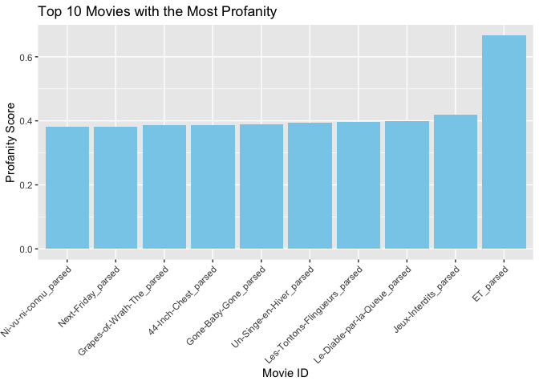

```r
## Measuring how appearance of profane words change over time
#https://cran.r-project.org/web/packages/tidytext/vignettes/tidying_casting.html

library(tidyverse)
library(stringr)
library(lubridate)

# Step 1: Download the list of profanities
profanity_url <- "https://www.cs.cmu.edu/~biglou/resources/bad-words.txt"
profanity_list <- readLines(profanity_url)

# Step 2: Preprocess the list and convert it into a vector of profanity words
profanity_words <- tolower(profanity_list)

# Step 3: Preprocess the movie scripts and count the occurrences of profanity words
# Assuming you have a dataframe named 'data_joined' containing movie scripts and release dates

# Function to count profanity words in a text
count_profanity <- function(text) {
  text <- tolower(text)
  count <- str_count(text, paste0("\\b", profanity_words, "\\b", collapse = "|"))
  return(sum(count))
}

# Apply the function to each movie script
data_joined$profanity_count <- sapply(data_joined$token, count_profanity)

# Step 4: Calculate the profanity score for each movie
# Profanity score is the count of profanity words normalized by the length of the script
data_joined$profanity_score <- data_joined$profanity_count / nchar(data_joined$token)

# Step 5: Visualize the top 10 movies with the most profanity
top_10_profanity <- data_joined %>%
  arrange(desc(profanity_score)) %>%
  head(10)

# Plot the top 10 movies with the most profanity
ggplot(top_10_profanity, aes(x = reorder(movie_id, profanity_score), y = profanity_score)) +
  geom_bar(stat = "identity", fill = "skyblue") +
  labs(title = "Top 10 Movies with the Most Profanity",
       x = "Movie ID",
       y = "Profanity Score") +
  theme(axis.text.x = element_text(angle = 45, hjust = 1))
```

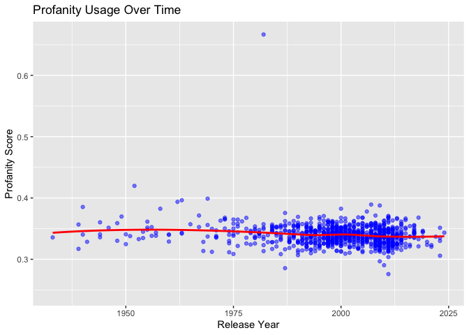

```r
# Step 6: Visualize how the use of profanity has changed over time
# Assuming 'release' column contains movie release dates

# Extract year from release date
data_joined$release_year <- data_joined$imdb_release_date

# Plot profanity score over time
ggplot(data_joined, aes(x = imdb_release_date, y = profanity_score)) +
  geom_point(alpha = 0.5, color="blue") +
  geom_smooth(method = "loess", se = FALSE, color = "red") +
  labs(title = "Profanity Usage Over Time",
       x = "Release Year",
       y = "Profanity Score")
```

##### e) Simplicity is a Virtue

Examine the impact of script simplicity on its success by calculating a readability score (Flesch Reading Ease, Flesch-Kincaid, or other measures) for the scripts. Analyze and visualize the relationship between the readability of the scripts and their IMDb vote average, providing commentary on your findings.

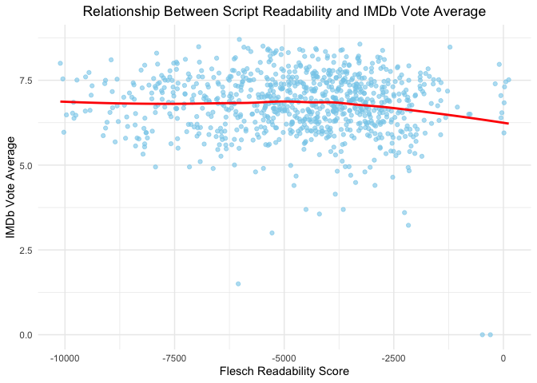

```r
library(stringi)
library(quanteda)
library(ggplot2)

# Calculate Flesch readability score for each movie script
data_joined$readability <- textstat_readability(data_joined$token,
                                                measure = "Flesch")$Flesch

# Create a scatter plot
ggplot(data_joined, aes(x = readability, y = vote_average)) +
  geom_point(color = "skyblue", alpha = 0.6) +  # Set point color and transparency
  geom_smooth(method = "loess", se = FALSE, color = "red") +  # Add smooth line
  labs(title = "Relationship Between Script Readability and IMDb Vote Average",
       x = "Flesch Readability Score",
       y = "IMDb Vote Average") +
  theme_minimal() +  # Set minimal theme
  theme(plot.title = element_text(hjust = 0.5))
```

#### 2. Genres

##### a) Defining words

Identify and visualize the most defining words across different movie genres using the TF-IDF measure. Utilize the `genre` variable from the movie metadata to differentiate and analyze the unique lexical footprint of each genre. Provide a visualization to highlight how different genres are defined by different words.

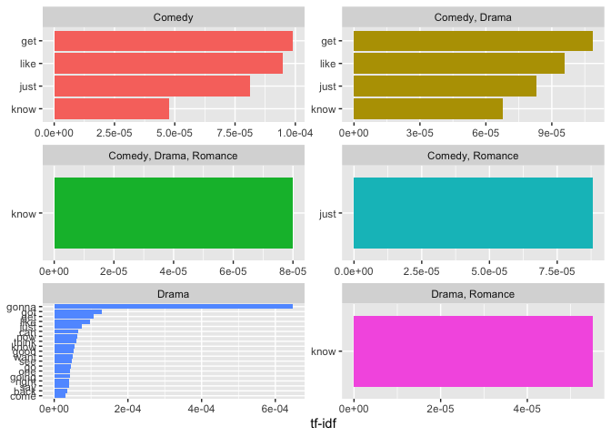

```r
library(dplyr)
library(tidyr)
library(ggplot2)
library(tidytext)

data2a <- select(data_joined,c(token, genres))
data2a = data2a[complete.cases(data2a), ]


data2a_words <- data2a %>%
  mutate(token = as.character(token)) %>%
  unnest_tokens(output = word, input = token) %>%
  count(genres, word, sort = TRUE)
data2a_words  <- data2a_words  %>%
  bind_tf_idf(term = word, document = genres, n)



 data2a_words %>% group_by(genres) %>%
   ungroup() %>%
   top_n(30) %>%
  ggplot(aes(tf_idf, fct_reorder(word, tf_idf), fill = genres)) +
  geom_col(show.legend = FALSE) +
  facet_wrap(~genres, ncol = 2, scales = "free") +
  labs(x = "tf-idf", y = NULL)
```

##### b) Emotions

Now, use the NRC Word-Emotion Association Lexicon in the `tidytext` package to identify a larger set of emotions (e.g. anger, anticipation, disgust, fear, joy, sadness, surprise, trust). Again, visualize the relationship between the use of words from these categories and the movie genre. What is your finding?

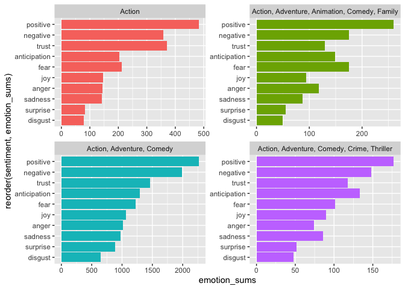

```r
library(tidytext)

# Check data types and convert if needed
data_joined$token <- as.character(data_joined$token)

# Prepare the data
emotion <- data_joined %>%
  select(token, genres) %>%
  drop_na() %>%
  count(token, genres) %>%
  bind_tf_idf(token, genres, n)

# Tokenize the data and count word frequencies
emotions_words <-emotion %>%
  unnest_tokens(output = word, input = token) %>%
  count(genres, word, sort = TRUE)

# Associate words with emotions using NRC lexicon
emotions <- get_sentiments("nrc")
if (is.null(emotions)) {
  stop("Error: NRC lexicon not available.")
}

emotions_words <- emotions_words %>%
  group_by(genres) %>%
  inner_join(emotions)

# Calculate emotion sums for each genre
emotion_sums <- emotions_words %>%
  group_by(genres, sentiment) %>%
  summarise(emotion_sums = sum(n)) %>%
  ungroup()

final= emotions_words %>%
  group_by(genres, sentiment) %>%
  summarise(emotion_sums=sum(n)) %>%
  group_by(genres)%>%
  ungroup()

 final%>%
  group_by(genres)%>%
  ungroup() %>% top_n(40) %>%
  ggplot(aes(x=reorder(sentiment,emotion_sums),y=emotion_sums,fill=genres)) +
  geom_col(show.legend = FALSE) +
  facet_wrap(~genres,scales="free") +
  coord_flip()
```

#### 3. Topic Modeling [**OPTIONAL ONLY**. Bonus points]

```r
library(topicmodels)
library(tm)
library(dplyr)
library(forcats)
library(ggplot2)


data_subset <- data_joined %>%
  select(token, imdb_release_date) %>%
  filter(imdb_release_date == '1990') %>%
  na.omit()

# Number of topics
num_topics <- 5

# Create Document-Term Matrix
DTM <- DocumentTermMatrix(Corpus(VectorSource(data_subset$token)),
                          control = list(bounds = list(global = c(3, Inf))))



# LDA model
topicModel <- LDA(DTM, num_topics, method = "Gibbs",
                  control = list(iter = 500, verbose = 25))
```

```
## K = 5; V = 2777; M = 17
## Sampling 500 iterations!
## Iteration 25 ...
## Iteration 50 ...
## Iteration 75 ...
## Iteration 100 ...
## Iteration 125 ...
## Iteration 150 ...
## Iteration 175 ...
## Iteration 200 ...
## Iteration 225 ...
## Iteration 250 ...
## Iteration 275 ...
## Iteration 300 ...
## Iteration 325 ...
## Iteration 350 ...
## Iteration 375 ...
## Iteration 400 ...
## Iteration 425 ...
## Iteration 450 ...
## Iteration 475 ...
## Iteration 500 ...
## Gibbs sampling completed!
```

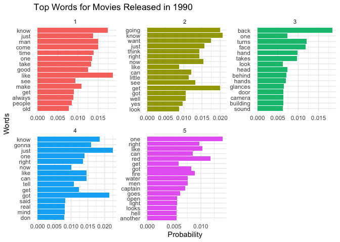

```r
# Extract top words for each topic
top_words <- tidy(topicModel, matrix = "beta") %>%
  group_by(topic) %>%
  top_n(15, beta) %>%
  ungroup() %>%
  mutate(term = fct_reorder(term, beta))

# Plotting
ggplot(top_words, aes(term, beta, fill = as.factor(topic))) +
  geom_col(show.legend = FALSE) +
  facet_wrap(~ topic, scales = "free") +
  coord_flip() +
  labs(title = "Top Words for Movies Released in 1990",
       x = "Words",
       y = "Probability") +
  theme_minimal()
```

```r
data_subset <- data_joined %>%
  select(token, imdb_release_date) %>%
  filter(imdb_release_date == '1960') %>%
  na.omit()



# Create Document-Term Matrix
DTM <- DocumentTermMatrix(Corpus(VectorSource(data_subset$token)),
                          control = list(bounds = list(global = c(3, Inf))))

set.seed(4)

# LDA model
topicModel <- LDA(DTM, num_topics, method = "Gibbs",
                  control = list(iter = 500, verbose = 25))
```

```
## K = 5; V = 328; M = 3
## Sampling 500 iterations!
## Iteration 25 ...
## Iteration 50 ...
## Iteration 75 ...
## Iteration 100 ...
## Iteration 125 ...
## Iteration 150 ...
## Iteration 175 ...
## Iteration 200 ...
## Iteration 225 ...
## Iteration 250 ...
## Iteration 275 ...
## Iteration 300 ...
## Iteration 325 ...
## Iteration 350 ...
## Iteration 375 ...
## Iteration 400 ...
## Iteration 425 ...
## Iteration 450 ...
## Iteration 475 ...
## Iteration 500 ...
## Gibbs sampling completed!
```

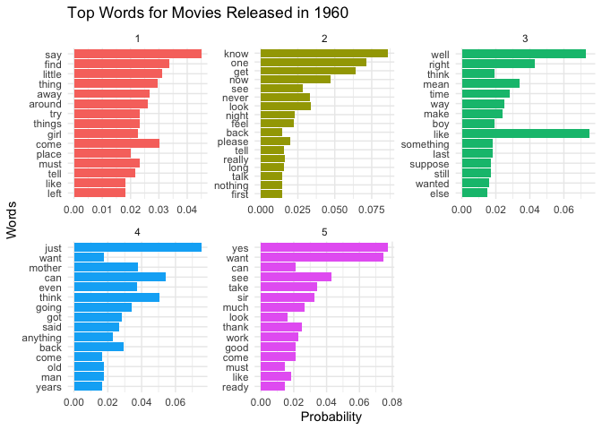

```r
# Extract top words for each topic
top_words <- tidy(topicModel, matrix = "beta") %>%
  group_by(topic) %>%
  top_n(15, beta) %>%
  ungroup() %>%
  mutate(term = fct_reorder(term, beta))

# Plotting
ggplot(top_words, aes(term, beta, fill = as.factor(topic))) +
  geom_col(show.legend = FALSE) +
  facet_wrap(~ topic, scales = "free") +
  coord_flip() +
  labs(title = "Top Words for Movies Released in 1960",
       x = "Words",
       y = "Probability") +
  theme_minimal()
```

Conduct a topic modeling analysis using LDA or STM on a manageable subset of the movie scripts. Create visualizations that illustrate the significant themes or topics uncovered in the analysis, and discuss the insights gained from the topic model.

## Submission

Please add the hash of your final commit in the feedback issue request to submit your homework. The homework is due on Monday, April 1 at noon.

#### Academic Integrity

Your submission should be your own original work. Inspiration and technique understanding from external sources are acceptable, but direct collaboration or copying is not permitted. Ensure your analysis and visualizations are uniquely crafted for this assignment.